# Analysis of the NOAA Storm Database

## Investigating the Most Harmful Events Across the United States

## Synopsis:

#### This study analizes the NOAA’s Storm Database to address two questions:

1. Across the United States, which types of events (as indicated in the EVTYPE variable) are most harmful with respect to population health? In this analysis, this will be described using the term “Health Cost”.
2. Across the United States, which types of events have the greatest economic consequences? In this analysis, this will be refered to as “Total Damage”.

#### The study consists of two main sections: **Data Processing**, and **Results**. The Dataloading and processing section contains code that loads the data from csv, subsets the data, and processes it to extract Damage and Health Cost values as well as reformat the date data for later use. The Results section presents Total Damage and Health Cost broken out by event type and state. One of the goals of this article is to issustrate the use of Dplyr’s Split-Apply-Combine workflow using the pipeline operator, groupby, and summarize. These functions provide powerful tools for aggreating and analyzing data based on multiple metrics. I also had fun exploring some new colors beyond R’s defaults with the viridis library.

## Data Processing:

#### Load the appropriate libraries:

```r
library(lubridate) # I did not end up using the date data, but it is embedded in my code, so...
library(plyr)
library(dplyr)
library(tidyr)
library(ggplot2)
library(gridExtra) # used to make panel plots of different variables.
library(viridis) # color palettes
library(maps)
library(mapproj)
```

### Next download the data and load it into a dataframe:

```r
if (!file.exists("StormData.csv.bz2")) {

        #URL's for the dataset, documentation, and FAQ's
        dataURL <- "https://d396qusza40orc.cloudfront.net/repdata%2Fdata%2FStormData.csv.bz2"

        download.file(dataURL, destfile = "StormData.csv.bz2")
}
stormData <- read.table("StormData.csv.bz2",
                        header=TRUE, sep = "," ,
                        stringsAsFactors = FALSE)

str(stormData)
```

```
## 'data.frame':    746004 obs. of  37 variables:
##  $ STATE__   : num  1 1 1 1 1 1 1 1 1 1 ...
##  $ BGN_DATE  : chr  "4/18/1950 0:00:00" "4/18/1950 0:00:00" "2/20/1951 0:00:00" "6/8/1951 0:00:00" ...
##  $ BGN_TIME  : chr  "0130" "0145" "1600" "0900" ...
##  $ TIME_ZONE : chr  "CST" "CST" "CST" "CST" ...
##  $ COUNTY    : num  97 3 57 89 43 77 9 123 125 57 ...
##  $ COUNTYNAME: chr  "MOBILE" "BALDWIN" "FAYETTE" "MADISON" ...
##  $ STATE     : chr  "AL" "AL" "AL" "AL" ...
##  $ EVTYPE    : chr  "TORNADO" "TORNADO" "TORNADO" "TORNADO" ...
##  $ BGN_RANGE : num  0 0 0 0 0 0 0 0 0 0 ...
##  $ BGN_AZI   : chr  "" "" "" "" ...
##  $ BGN_LOCATI: chr  "" "" "" "" ...
##  $ END_DATE  : chr  "" "" "" "" ...
##  $ END_TIME  : chr  "" "" "" "" ...
##  $ COUNTY_END: num  0 0 0 0 0 0 0 0 0 0 ...
```

[output cut: 23 more lines]

#### Observation: Many of the columns in this dataset are not needed for this analysis.

#### Select only the Columns needed to analyze Damage and Health Cost:

```r
# Select only the needed columns into "data"

data <- stormData %>%
                select(BGN_DATE,
                        STATE,
                        EVTYPE,
                        FATALITIES,
                        INJURIES,
                        PROPDMG,
                        PROPDMGEXP,
                        CROPDMG,
                        CROPDMGEXP)
```

#### Remove any rows that contain zero values for PROPDMG, CROPDMG, INJURIES, or FATALITIES:

- If an event did not cause any sort of damage it is not required for this analysis.

#### Remove data for Territories and Military Bases.

- While it is not explicity stated in the Assignment Instructions, I am assuming the analysis is for the 50 states, so I’m removing data for territories and bases to simplify the dataset.

```r
# Remove any rows that do not have any reported damage or health effect:

isDamage <- ((data$PROPDMG != 0) | (data$CROPDMG != 0))
isHealthEffect <- ((data$FATALITIES != 0) | (data$INJURIES != 0))

data<- subset(data,isDamage | isHealthEffect)

# Remove Territories and Military bases so that the dataset consists of the 50 states and D.C.
stateAbbreviations <- read.csv("stateAbbreviations.csv")
data <- subset(data, STATE %in% stateAbbreviations$STATE)
```

#### Calculate Damage and Health Cost:

- Damage values are stored in exponent form with the mantissa stored in PROPDMG and CROPDMG and the exponents stored as “K”, “M”,or “B”" for Thousand, Million, or Billion. So I need to calculate actual dollar values from PROPDMG and CROPDMG columns using the codes found in PROPDMGEXP and CROPDMGEXP
- Once dollar amounts are calcuated for Property Damage and Crop Damage, a Damage variable can be calculated by adding these values together. A Health Cost variable is calculated by adding Fatalities and Injuries.
- This code chunk also reformats the BGN_DATE data to extract Year and Month. I did not end up using the date data.

```r
# Define list used to map from dollar codes to values
expKey <- c('K' = 1000, 'M' = 1000000, 'B' = 1000000000)

data['pExp'] <- revalue(x = data$PROPDMGEXP,expKey)
data['cExp'] <- revalue(x = data$CROPDMGEXP,expKey)
data <- data %>% mutate(pDamageDollars = PROPDMG * as.integer(pExp)) %>%
                 mutate(cDamageDollars = CROPDMG * as.integer(cExp)) %>%
                 replace_na(replace = list(pDamageDollars = 0, cDamageDollars = 0))

# Calculate total damage and total health cost columns and reformat date.
data <- data %>%
        mutate(damage =  cDamageDollars + pDamageDollars) %>%
        mutate(healthCost = FATALITIES + INJURIES) %>%
        mutate(date = mdy_hms(BGN_DATE)) %>%
        mutate(Year = year(date)) %>%
        mutate(Month = month(date))

head(data)
```

```
##             BGN_DATE STATE  EVTYPE FATALITIES INJURIES PROPDMG PROPDMGEXP
## 1  4/18/1950 0:00:00    AL TORNADO          0       15    25.0          K
## 2  4/18/1950 0:00:00    AL TORNADO          0        0     2.5          K
## 3  2/20/1951 0:00:00    AL TORNADO          0        2    25.0          K
## 4   6/8/1951 0:00:00    AL TORNADO          0        2     2.5          K
## 5 11/15/1951 0:00:00    AL TORNADO          0        2     2.5          K
## 6 11/15/1951 0:00:00    AL TORNADO          0        6     2.5          K
##   CROPDMG CROPDMGEXP pExp cExp pDamageDollars cDamageDollars damage
## 1       0            1000               25000              0  25000
## 2       0            1000                2500              0   2500
## 3       0            1000               25000              0  25000
## 4       0            1000                2500              0   2500
## 5       0            1000                2500              0   2500
## 6       0            1000                2500              0   2500
##   healthCost       date Year Month
## 1         15 1950-04-18 1950     4
## 2          0 1950-04-18 1950     4
## 3          2 1951-02-20 1951     2
## 4          2 1951-06-08 1951     6
## 5          2 1951-11-15 1951    11
## 6          6 1951-11-15 1951    11
```

## Results:

- For this analysis, I will used total damage as my metric. ie, the sum of all damage for a given event type, in a given state, etc. There are many other metrics that could be used that would yield additional insights, but given the limit of 3 plots for this project, looking at simple totals seems appropriate. Because most of the damage and Health Cost is inficted by only a few events, I will only look at the most impactful:

### Figure 1:

#### Plot total damage and total health cost by event type for the entire country.

- Note that Health Cost is displayed on a semi-log scale.

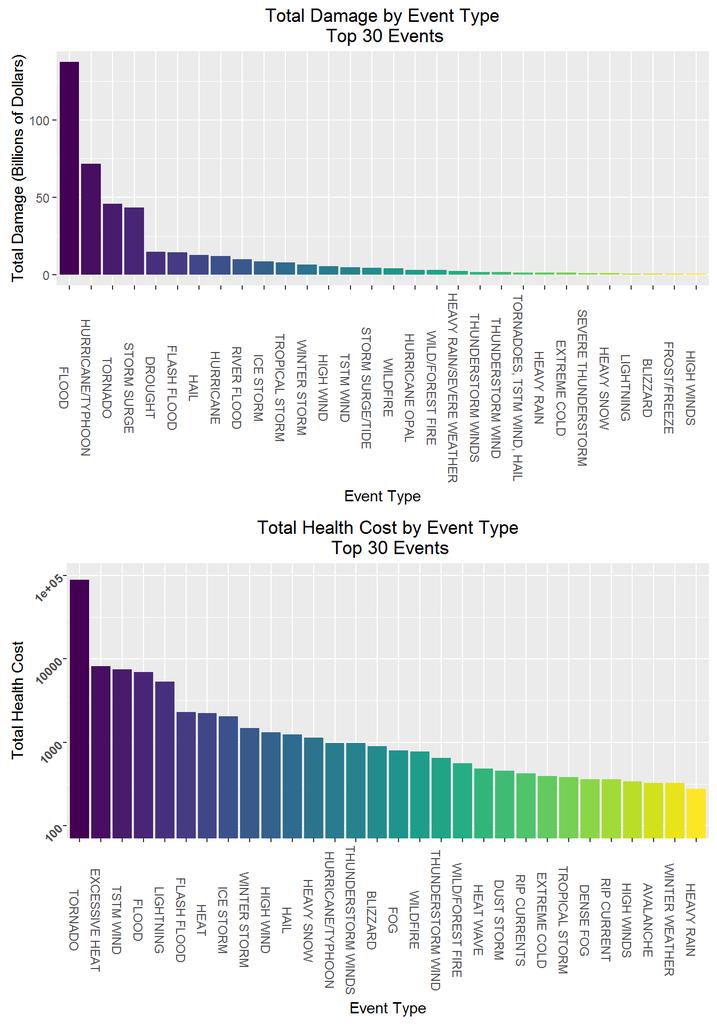

```r
#  Group and sum by event type to see
#  the most costly event for the entire country.
NationalDamageTotal <- data %>%
                group_by(EVTYPE) %>%
                summarize(totalDamage = sum(damage), totalHealthCost = sum(healthCost)) %>%
                arrange(desc(totalDamage))

# The dataframe is sorted by total damage, but to get the barplot to
# plot in descending order the event types "EVTYPE" need to be ordered factors:
NationalDamageTotal <- within(NationalDamageTotal,
                   EVTYPE<- factor(EVTYPE,
                                      levels=EVTYPE))

NationalHealthTotal <- data %>%
        group_by(EVTYPE) %>%
        summarize(totalHealthCost = sum(healthCost)) %>%
        arrange(desc(totalHealthCost))

# The dataframe is sorted by total damage, but to get the barplot to
# plot in descending order the event types "EVTYPE" need to be ordered factors:
NationalHealthTotal <- within(NationalHealthTotal,
                              EVTYPE<- factor(EVTYPE,
                                              levels=EVTYPE))
# Now make the plot
billion = 1000000000
damagePlot <- ggplot(NationalDamageTotal[1:30,], aes(EVTYPE, totalDamage/billion, fill = EVTYPE)) +
     geom_bar(stat = "identity") +
        theme(axis.text.x = element_text(angle = 270),
              legend.position = 'none') +
        scale_fill_viridis(begin = 0, end = 1, discrete=TRUE, direction = 1)+
        labs(title = "Total Damage by Event Type\n Top 30 Events",
             x = "Event Type",
             y = "Total Damage (Billions of Dollars)")
HealthPlot <- ggplot(NationalHealthTotal[1:30,], aes(EVTYPE, totalHealthCost, fill = EVTYPE)) +
        geom_bar(stat = "identity") +
        theme(axis.text.x = element_text(angle = 270),
              legend.position = 'none') +
        scale_fill_viridis(begin = 0, end = 1, discrete=TRUE, direction = 1)+
        coord_cartesian(ylim=c(100,100000)) +
        scale_y_log10(limits = c(1,100000),
                      breaks = c(100, 1000, 10000, 100000),
                      labels = c( 100, 1000, 10000, 100000)) +
        theme(axis.text.y = element_text(face = "bold", angle = 45)) +
        labs(title = "Total Health Cost by Event Type\n Top 30 Events",
             x = "Event Type",
             y = "Total Health Cost")
grid.arrange(damagePlot, HealthPlot)
```

#### This panel plot shows that historically, Flooding has cased the greatest amount of damage, followed by Hurricane/Typhoon, Tornado, Storm Surge and Drought.

#### The Tornados have caused the greated Health Cost, followed by Excessive Heat, TSTM Wind, Flood, and Lighting.

#### These top 5 event types for Damage and Health Cost will be further analyzed below.

### Figure 2:

#### Panel Plot of the top 5 Events by State.

- Because most of the Damage in the country is caused by the top 5 Events listed above, the following plot will map those events showing Total Damage in each State. States that do not show up have zero damage for the given category.

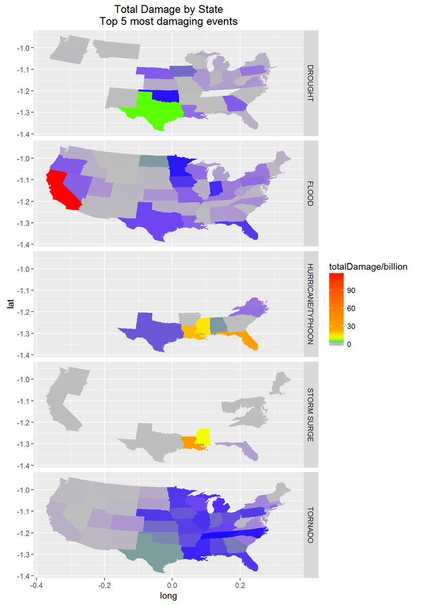

```r
#-------------------------------------------------------------------------------
# Total Damage for each state
#-------------------------------------------------------------------------------
top5Damage <- NationalDamageTotal$EVTYPE[1:5]


top5Damage_data <- subset(data, EVTYPE %in% top5Damage)

StateDamageTotals <- top5Damage_data %>%
                  group_by(STATE, EVTYPE) %>%
                  summarise(totalDamage = sum(damage)) %>%
                  complete(EVTYPE,fill = list(totalDamage = 0)) %>%
                  arrange(STATE,desc(totalDamage))


stateAbbreviations <- read.csv("stateAbbreviations.csv") #read in state abbreviations in order to merge data below
state <- merge(StateDamageTotals, stateAbbreviations, by = 'STATE')
state$stateName <- tolower(state$stateName)

# use the "map" library to define a dataframe with state ploygon data to create a map with ggplot
state_df <- map_data("state", projection = "albers", parameters = c(39, 45))
names(state_df) = c("long","lat","group","order", "stateName","subregion")

map_state <- merge(state_df, state, by = 'stateName')

stateDamageMap <- ggplot(map_state,
                         aes(long, lat, group = group, fill = totalDamage/billion)) +
                  geom_polygon() + #scale_fill_viridis( direction = -1) +
                  scale_fill_gradientn(colors = c("red","orange","yellow","green","blue", 'grey'),
                                       values = c(1, 0.2, 0.1, 0.05, 0.01, 0), na.value = 'grey') +
                  facet_grid(EVTYPE~.) +
                  labs(title = "Total Damage by State\nTop 5 most damaging events")
stateDamageMap
```

#### This Plot illustrates the geographic distribution of the 5 most damage-causing events, as identified earlier in the anaysis. Storm SUrge and Hurricane/Typhoon are limited to coastal states, primarily in the Gulf. Drought damage is mainly located in the Southwest, Midwest, and East Coast. Tornado Damage is focused in the midwest. Flood Damage is spread across the country, with the most damage occuring in California.

### Plot3:

#### Panel Plot of the top 5 Health Cost Events by State.

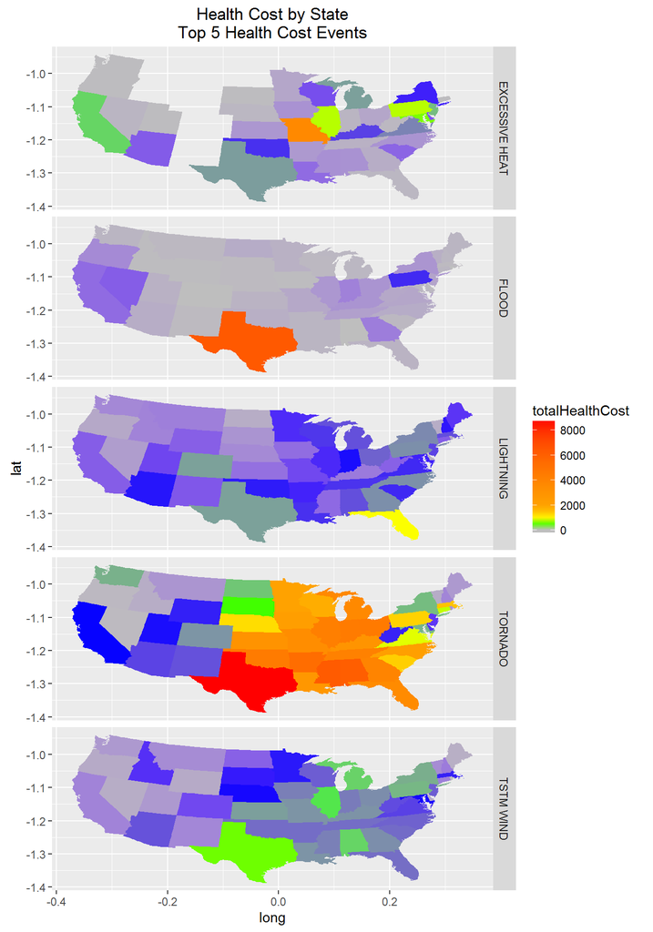

```r
#-----------------------------------------------------------------------------------
# Health Cost by state
#-----------------------------------------------------------------------------------

top5Health <- NationalHealthTotal$EVTYPE[1:5]

top5Health_data <- subset(data, EVTYPE %in% top5Health)

StateHealthTotals <- top5Health_data %>%
        group_by(STATE, EVTYPE) %>%
        summarise(totalHealthCost = sum(healthCost)) %>%
        arrange(desc(totalHealthCost))



stateHealthTotals <- merge(StateHealthTotals, stateAbbreviations, by = 'STATE')
stateHealthTotals$stateName <- tolower(stateHealthTotals$stateName)

#state_df <- map_data("state", projection = "albers", parameters = c(39, 45))
#names(state_df) = c("long","lat","group","order", "stateName","subregion")

stateHealthTotals <- merge(state_df, stateHealthTotals, by = 'stateName')

stateHealthMap <- ggplot(stateHealthTotals,
                         aes(long, lat, group = group, fill = totalHealthCost)) +
        geom_polygon() + #scale_fill_viridis( direction = -1)+
        scale_fill_gradientn(colors = c("red","orange","yellow","green","blue", 'grey'),
                     values = c(1, 0.2, 0.1, 0.05, 0.01, 0), na.value = 'grey') +
        facet_grid(EVTYPE~.) +
        labs(title = "Health Cost by State\nTop 5 Health Cost Events")
stateHealthMap
```

#### This Plot illustrates the geographic distribution of the 5 highest Health Cost Events, as identified earlier in the anaysis. While several of these events seem to spread across the country with some uniformity, Excessive heat has focal points in California, the midwest, ande New England. Health Cost from Flooding is concentrated in Texas, and Health Cost from Tornado is focused in the mid-continent. Since this data has not been normalized to population, some of the observed distributions may be affected by population density.

### Conclusions:

#### Obviously, a lot more can be done with this dataset. This was a first pass analysis designed to pull to most impactful events out of the dataset and show the geographic distrbution of the events. One of the points of the analysis was to show that, once your data is loaded into R and cleaned appropriately it is relatively easy to aggreate and filter the data by various metrics using Dplyr’s Split-Apply-Compbine workflow with the pipeline operator and mutate, groupby, and summarize functions. Further analysis could break the events down by county, and analyze the seasonal distribution of events, or focus on particular states with the most damage.